# Risk Factor Analysis

## Outcome Variable

**Outcome Variable:** whz

## Predictor Variables

**Intervention Variable:** nchldlt5

**Adjustment Set:**

- arm
- W_mage
- meducyrs
- feducyrs
- hhwealth_quart
- hfoodsec
- W_mhtcm
- W_mwtkg
- W_mbmi
- W_nrooms
- W_parity
- impfloor
- impsan
- safeh20
- delta_W_mage
- delta_meducyrs
- delta_feducyrs
- delta_hhwealth_quart
- delta_hfoodsec
- delta_W_mhtcm
- delta_W_mwtkg
- delta_W_mbmi
- delta_W_nrooms
- delta_W_parity
- delta_impfloor
- delta_impsan
- delta_safeh20

## Stratifying Variables

The analysis was stratified on these variable(s):

- agecat
- studyid
- country

## Data Summary

| agecat | studyid | country | nchldlt5 | n_cell | n | outcome_variable |
| --- | --- | --- | --- | --- | --- | --- |
| Birth | IRC | INDIA | 1 | 72 | 343 | whz |
| Birth | IRC | INDIA | 2+ | 271 | 343 | whz |
| Birth | JiVitA-3 | BANGLADESH | 1 | 10878 | 17991 | whz |
| Birth | JiVitA-3 | BANGLADESH | 2+ | 7113 | 17991 | whz |
| Birth | NIH-Crypto | BANGLADESH | 1 | 504 | 707 | whz |
| Birth | NIH-Crypto | BANGLADESH | 2+ | 203 | 707 | whz |
| Birth | PROVIDE | BANGLADESH | 1 | 385 | 532 | whz |
| Birth | PROVIDE | BANGLADESH | 2+ | 147 | 532 | whz |
| 6 months | IRC | INDIA | 1 | 88 | 408 | whz |
| 6 months | IRC | INDIA | 2+ | 320 | 408 | whz |
| 6 months | JiVitA-3 | BANGLADESH | 1 | 10872 | 16773 | whz |
| 6 months | JiVitA-3 | BANGLADESH | 2+ | 5901 | 16773 | whz |
| 6 months | LCNI-5 | MALAWI | 1 | 390 | 811 | whz |
| 6 months | LCNI-5 | MALAWI | 2+ | 421 | 811 | whz |
| 6 months | NIH-Crypto | BANGLADESH | 1 | 507 | 715 | whz |
| 6 months | NIH-Crypto | BANGLADESH | 2+ | 208 | 715 | whz |
| 6 months | PROVIDE | BANGLADESH | 1 | 438 | 603 | whz |
| 6 months | PROVIDE | BANGLADESH | 2+ | 165 | 603 | whz |
| 6 months | TanzaniaChild2 | TANZANIA, UNITED REPUBLIC OF | 1 | 1390 | 2019 | whz |
| 6 months | TanzaniaChild2 | TANZANIA, UNITED REPUBLIC OF | 2+ | 629 | 2019 | whz |
| 24 months | IRC | INDIA | 1 | 89 | 409 | whz |
| 24 months | IRC | INDIA | 2+ | 320 | 409 | whz |
| 24 months | JiVitA-3 | BANGLADESH | 1 | 5434 | 8593 | whz |
| 24 months | JiVitA-3 | BANGLADESH | 2+ | 3159 | 8593 | whz |
| 24 months | LCNI-5 | MALAWI | 1 | 277 | 555 | whz |
| 24 months | LCNI-5 | MALAWI | 2+ | 278 | 555 | whz |
| 24 months | NIH-Crypto | BANGLADESH | 1 | 357 | 514 | whz |
| 24 months | NIH-Crypto | BANGLADESH | 2+ | 157 | 514 | whz |
| 24 months | PROVIDE | BANGLADESH | 1 | 424 | 579 | whz |
| 24 months | PROVIDE | BANGLADESH | 2+ | 155 | 579 | whz |
| 24 months | TanzaniaChild2 | TANZANIA, UNITED REPUBLIC OF | 1 | 5 | 6 | whz |
| 24 months | TanzaniaChild2 | TANZANIA, UNITED REPUBLIC OF | 2+ | 1 | 6 | whz |

The following strata were considered:

- agecat: 24 months, studyid: IRC, country: INDIA
- agecat: 24 months, studyid: JiVitA-3, country: BANGLADESH
- agecat: 24 months, studyid: LCNI-5, country: MALAWI
- agecat: 24 months, studyid: NIH-Crypto, country: BANGLADESH
- agecat: 24 months, studyid: PROVIDE, country: BANGLADESH
- agecat: 24 months, studyid: TanzaniaChild2, country: TANZANIA, UNITED REPUBLIC OF
- agecat: 6 months, studyid: IRC, country: INDIA
- agecat: 6 months, studyid: JiVitA-3, country: BANGLADESH
- agecat: 6 months, studyid: LCNI-5, country: MALAWI
- agecat: 6 months, studyid: NIH-Crypto, country: BANGLADESH
- agecat: 6 months, studyid: PROVIDE, country: BANGLADESH
- agecat: 6 months, studyid: TanzaniaChild2, country: TANZANIA, UNITED REPUBLIC OF
- agecat: Birth, studyid: IRC, country: INDIA
- agecat: Birth, studyid: JiVitA-3, country: BANGLADESH
- agecat: Birth, studyid: NIH-Crypto, country: BANGLADESH
- agecat: Birth, studyid: PROVIDE, country: BANGLADESH

### Dropped Strata

Some strata were dropped due to rare outcomes:

- agecat: 24 months, studyid: TanzaniaChild2, country: TANZANIA, UNITED REPUBLIC OF

## Methods Detail

We’re interested in the causal parameters $E[Y_a]$ for all values of $a \in \mathcal{A}$. These parameters represent the mean outcome if, possibly contrary to fact, we intervened to set all units to have $A=a$. Under the randomization and positivity assumptions, these are identified by the statistical parameters $\psi_a=E_W[E_{Y|A,W}(Y|A=a,W)]$. In addition, we’re interested in the mean of $Y$, $E[Y]$ under no intervention (the observed mean). We will estimate these parameters by using SuperLearner to fit the relevant likelihood factors – $E_{Y|A,W}(Y|A=a,W)$ and $p(A=a|W)$, and then updating our likelihood fit using a joint TMLE.

For unadjusted analyses ($W=\{\}$), initial likelihoods were estimated using Lrnr_glm to estimate the simple $E(Y|A)$ and Lrnr_mean to estimate $p(A)$. For adjusted analyses, a small library containing Lrnr_glmnet, Lrnr_xgboost, and Lrnr_mean was used.

Having estimated these parameters, we will then use the delta method to estimate relative risks and attributable risks relative to a prespecified baseline level of $A$.

# Results Detail

## Results Plots

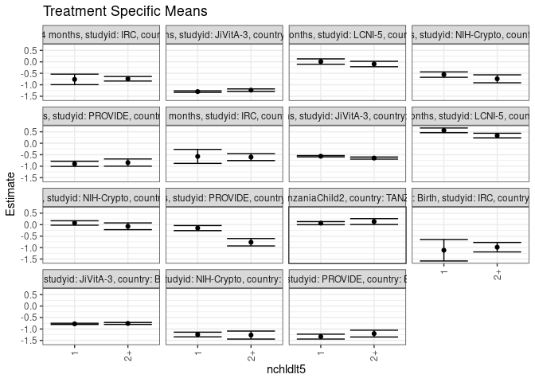

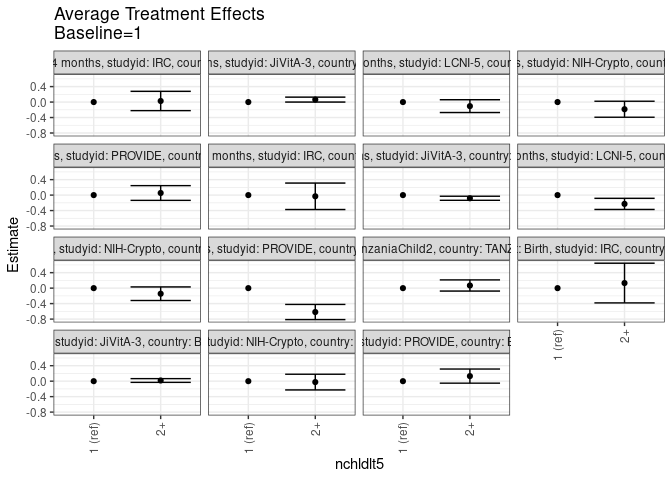

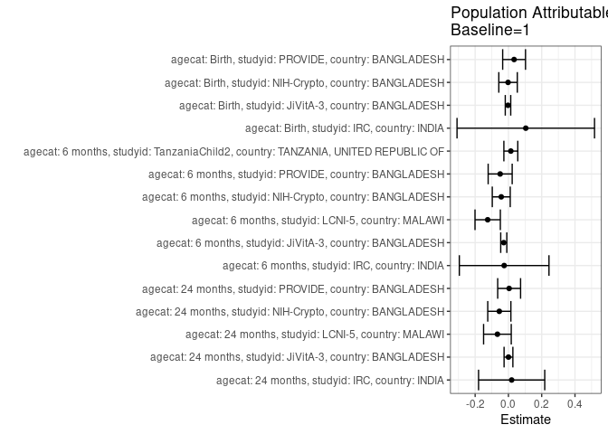

## Results Table

### Parameter: TSM

| agecat | studyid | country | intervention_level | baseline_level | estimate | ci_lower | ci_upper |
| --- | --- | --- | --- | --- | --- | --- | --- |
| Birth | IRC | INDIA | 1 | NA | -1.1148248 | -1.5843859 | -0.6452638 |
| Birth | IRC | INDIA | 2+ | NA | -0.9832910 | -1.1898561 | -0.7767259 |
| Birth | JiVitA-3 | BANGLADESH | 1 | NA | -0.7751156 | -0.8010455 | -0.7491857 |
| Birth | JiVitA-3 | BANGLADESH | 2+ | NA | -0.7573168 | -0.7991306 | -0.7155030 |
| Birth | NIH-Crypto | BANGLADESH | 1 | NA | -1.2419426 | -1.3444939 | -1.1393913 |
| Birth | NIH-Crypto | BANGLADESH | 2+ | NA | -1.2652803 | -1.4403266 | -1.0902341 |
| Birth | PROVIDE | BANGLADESH | 1 | NA | -1.3325324 | -1.4386170 | -1.2264478 |
| Birth | PROVIDE | BANGLADESH | 2+ | NA | -1.2011910 | -1.3501634 | -1.0522186 |
| 6 months | IRC | INDIA | 1 | NA | -0.5732971 | -0.8789113 | -0.2676828 |
| 6 months | IRC | INDIA | 2+ | NA | -0.6042427 | -0.7566648 | -0.4518206 |
| 6 months | JiVitA-3 | BANGLADESH | 1 | NA | -0.5652261 | -0.5921560 | -0.5382963 |
| 6 months | JiVitA-3 | BANGLADESH | 2+ | NA | -0.6473330 | -0.6934993 | -0.6011668 |
| 6 months | LCNI-5 | MALAWI | 1 | NA | 0.5626390 | 0.4596247 | 0.6656533 |
| 6 months | LCNI-5 | MALAWI | 2+ | NA | 0.3349671 | 0.2338781 | 0.4360561 |
| 6 months | NIH-Crypto | BANGLADESH | 1 | NA | 0.0728697 | -0.0234615 | 0.1692008 |
| 6 months | NIH-Crypto | BANGLADESH | 2+ | NA | -0.0714983 | -0.2185483 | 0.0755517 |
| 6 months | PROVIDE | BANGLADESH | 1 | NA | -0.1494748 | -0.2606405 | -0.0383090 |
| 6 months | PROVIDE | BANGLADESH | 2+ | NA | -0.7672725 | -0.9279087 | -0.6066364 |
| 6 months | TanzaniaChild2 | TANZANIA, UNITED REPUBLIC OF | 1 | NA | 0.0657289 | -0.0017193 | 0.1331771 |
| 6 months | TanzaniaChild2 | TANZANIA, UNITED REPUBLIC OF | 2+ | NA | 0.1343616 | 0.0068461 | 0.2618771 |
| 24 months | IRC | INDIA | 1 | NA | -0.7652214 | -0.9939050 | -0.5365379 |
| 24 months | IRC | INDIA | 2+ | NA | -0.7376955 | -0.8367625 | -0.6386285 |
| 24 months | JiVitA-3 | BANGLADESH | 1 | NA | -1.2976166 | -1.3328703 | -1.2623629 |
| 24 months | JiVitA-3 | BANGLADESH | 2+ | NA | -1.2338070 | -1.2870364 | -1.1805777 |
| 24 months | LCNI-5 | MALAWI | 1 | NA | 0.0114160 | -0.1062824 | 0.1291143 |
| 24 months | LCNI-5 | MALAWI | 2+ | NA | -0.0938575 | -0.2122178 | 0.0245027 |
| 24 months | NIH-Crypto | BANGLADESH | 1 | NA | -0.5556092 | -0.6726347 | -0.4385837 |
| 24 months | NIH-Crypto | BANGLADESH | 2+ | NA | -0.7405719 | -0.9139857 | -0.5671581 |
| 24 months | PROVIDE | BANGLADESH | 1 | NA | -0.8971845 | -1.0103103 | -0.7840588 |
| 24 months | PROVIDE | BANGLADESH | 2+ | NA | -0.8425811 | -0.9989448 | -0.6862175 |

### Parameter: E(Y)

| agecat | studyid | country | intervention_level | baseline_level | estimate | ci_lower | ci_upper |
| --- | --- | --- | --- | --- | --- | --- | --- |
| Birth | IRC | INDIA | NA | NA | -1.0105831 | -1.1973019 | -0.8238643 |
| Birth | JiVitA-3 | BANGLADESH | NA | NA | -0.7776666 | -0.7966629 | -0.7586703 |
| Birth | NIH-Crypto | BANGLADESH | NA | NA | -1.2441513 | -1.3281130 | -1.1601897 |
| Birth | PROVIDE | BANGLADESH | NA | NA | -1.2984586 | -1.3752758 | -1.2216415 |
| 6 months | IRC | INDIA | NA | NA | -0.5989297 | -0.7344491 | -0.4634104 |
| 6 months | JiVitA-3 | BANGLADESH | NA | NA | -0.5932472 | -0.6127728 | -0.5737215 |
| 6 months | LCNI-5 | MALAWI | NA | NA | 0.4379655 | 0.3664533 | 0.5094777 |
| 6 months | NIH-Crypto | BANGLADESH | NA | NA | 0.0297622 | -0.0491685 | 0.1086930 |
| 6 months | PROVIDE | BANGLADESH | NA | NA | -0.1990907 | -0.2817968 | -0.1163845 |
| 6 months | TanzaniaChild2 | TANZANIA, UNITED REPUBLIC OF | NA | NA | 0.0801680 | 0.0273223 | 0.1330136 |
| 24 months | IRC | INDIA | NA | NA | -0.7458150 | -0.8368180 | -0.6548120 |
| 24 months | JiVitA-3 | BANGLADESH | NA | NA | -1.2972908 | -1.3206179 | -1.2739638 |
| 24 months | LCNI-5 | MALAWI | NA | NA | -0.0547297 | -0.1370054 | 0.0275459 |
| 24 months | NIH-Crypto | BANGLADESH | NA | NA | -0.6103502 | -0.7050157 | -0.5156847 |
| 24 months | PROVIDE | BANGLADESH | NA | NA | -0.8928670 | -0.9755153 | -0.8102187 |

### Parameter: ATE

| agecat | studyid | country | intervention_level | baseline_level | estimate | ci_lower | ci_upper |
| --- | --- | --- | --- | --- | --- | --- | --- |
| Birth | IRC | INDIA | 1 | 1 | 0.0000000 | 0.0000000 | 0.0000000 |
| Birth | IRC | INDIA | 2+ | 1 | 0.1315338 | -0.3816958 | 0.6447635 |
| Birth | JiVitA-3 | BANGLADESH | 1 | 1 | 0.0000000 | 0.0000000 | 0.0000000 |
| Birth | JiVitA-3 | BANGLADESH | 2+ | 1 | 0.0177988 | -0.0307205 | 0.0663180 |
| Birth | NIH-Crypto | BANGLADESH | 1 | 1 | 0.0000000 | 0.0000000 | 0.0000000 |
| Birth | NIH-Crypto | BANGLADESH | 2+ | 1 | -0.0233377 | -0.2263550 | 0.1796796 |
| Birth | PROVIDE | BANGLADESH | 1 | 1 | 0.0000000 | 0.0000000 | 0.0000000 |
| Birth | PROVIDE | BANGLADESH | 2+ | 1 | 0.1313413 | -0.0517930 | 0.3144757 |
| 6 months | IRC | INDIA | 1 | 1 | 0.0000000 | 0.0000000 | 0.0000000 |
| 6 months | IRC | INDIA | 2+ | 1 | -0.0309456 | -0.3732065 | 0.3113153 |
| 6 months | JiVitA-3 | BANGLADESH | 1 | 1 | 0.0000000 | 0.0000000 | 0.0000000 |
| 6 months | JiVitA-3 | BANGLADESH | 2+ | 1 | -0.0821069 | -0.1349532 | -0.0292607 |
| 6 months | LCNI-5 | MALAWI | 1 | 1 | 0.0000000 | 0.0000000 | 0.0000000 |
| 6 months | LCNI-5 | MALAWI | 2+ | 1 | -0.2276719 | -0.3716927 | -0.0836511 |
| 6 months | NIH-Crypto | BANGLADESH | 1 | 1 | 0.0000000 | 0.0000000 | 0.0000000 |
| 6 months | NIH-Crypto | BANGLADESH | 2+ | 1 | -0.1443680 | -0.3200079 | 0.0312720 |
| 6 months | PROVIDE | BANGLADESH | 1 | 1 | 0.0000000 | 0.0000000 | 0.0000000 |
| 6 months | PROVIDE | BANGLADESH | 2+ | 1 | -0.6177978 | -0.8137251 | -0.4218705 |
| 6 months | TanzaniaChild2 | TANZANIA, UNITED REPUBLIC OF | 1 | 1 | 0.0000000 | 0.0000000 | 0.0000000 |
| 6 months | TanzaniaChild2 | TANZANIA, UNITED REPUBLIC OF | 2+ | 1 | 0.0686327 | -0.0758301 | 0.2130955 |
| 24 months | IRC | INDIA | 1 | 1 | 0.0000000 | 0.0000000 | 0.0000000 |
| 24 months | IRC | INDIA | 2+ | 1 | 0.0275260 | -0.2221324 | 0.2771843 |
| 24 months | JiVitA-3 | BANGLADESH | 1 | 1 | 0.0000000 | 0.0000000 | 0.0000000 |
| 24 months | JiVitA-3 | BANGLADESH | 2+ | 1 | 0.0638096 | 0.0000894 | 0.1275297 |
| 24 months | LCNI-5 | MALAWI | 1 | 1 | 0.0000000 | 0.0000000 | 0.0000000 |
| 24 months | LCNI-5 | MALAWI | 2+ | 1 | -0.1052735 | -0.2706340 | 0.0600870 |
| 24 months | NIH-Crypto | BANGLADESH | 1 | 1 | 0.0000000 | 0.0000000 | 0.0000000 |
| 24 months | NIH-Crypto | BANGLADESH | 2+ | 1 | -0.1849627 | -0.3920232 | 0.0220979 |
| 24 months | PROVIDE | BANGLADESH | 1 | 1 | 0.0000000 | 0.0000000 | 0.0000000 |
| 24 months | PROVIDE | BANGLADESH | 2+ | 1 | 0.0546034 | -0.1357424 | 0.2449493 |

### Parameter: PAR

| agecat | studyid | country | intervention_level | baseline_level | estimate | ci_lower | ci_upper |
| --- | --- | --- | --- | --- | --- | --- | --- |
| Birth | IRC | INDIA | 1 | NA | 0.1042417 | -0.3089185 | 0.5174020 |
| Birth | JiVitA-3 | BANGLADESH | 1 | NA | -0.0025510 | -0.0189895 | 0.0138875 |
| Birth | NIH-Crypto | BANGLADESH | 1 | NA | -0.0022087 | -0.0577605 | 0.0533431 |
| Birth | PROVIDE | BANGLADESH | 1 | NA | 0.0340737 | -0.0345463 | 0.1026937 |
| 6 months | IRC | INDIA | 1 | NA | -0.0256327 | -0.2949749 | 0.2437095 |
| 6 months | JiVitA-3 | BANGLADESH | 1 | NA | -0.0280211 | -0.0462672 | -0.0097749 |
| 6 months | LCNI-5 | MALAWI | 1 | NA | -0.1246735 | -0.2007707 | -0.0485764 |
| 6 months | NIH-Crypto | BANGLADESH | 1 | NA | -0.0431074 | -0.0970695 | 0.0108546 |
| 6 months | PROVIDE | BANGLADESH | 1 | NA | -0.0496159 | -0.1218102 | 0.0225784 |
| 6 months | TanzaniaChild2 | TANZANIA, UNITED REPUBLIC OF | 1 | NA | 0.0144391 | -0.0273575 | 0.0562357 |
| 24 months | IRC | INDIA | 1 | NA | 0.0194064 | -0.1794716 | 0.2182845 |
| 24 months | JiVitA-3 | BANGLADESH | 1 | NA | 0.0003258 | -0.0260908 | 0.0267423 |
| 24 months | LCNI-5 | MALAWI | 1 | NA | -0.0661457 | -0.1492475 | 0.0169561 |
| 24 months | NIH-Crypto | BANGLADESH | 1 | NA | -0.0547409 | -0.1242454 | 0.0147635 |
| 24 months | PROVIDE | BANGLADESH | 1 | NA | 0.0043175 | -0.0644689 | 0.0731040 |